# MSc ENR ISM: Exercise C

Author

Marius King

Published

May 3, 2025

Abstract

Analysis of ecological indicator values (Dengler et al. 2023) and functional traits (Kleyer et al. 2008) from vegetation data of swiss grassland using R v4.5.0 (R Core Team 2025).

### *setup*

```r
pacman::p_load("tidyverse", "patchwork", "FD", "ggpubr", "patchwork", "knitr")

set.seed(123)

theme_set(
  theme_minimal()+
  theme(
    strip.background = element_rect(fill = "black"),
    strip.text = element_text(color = "white"),
    panel.spacing = unit(0.5, "lines"),
    axis.text = element_text(color = gray(0.3)),
    panel.border = element_rect(color = "black",fill=NA)
  )
)

niche_colormap <- c(
  moisture = "#e96e72",
  nitrogen = "#b4b927",
  reaction = "#43c2a9",
  light = "#2ba8e1",
  temperature = "#c17ab9"
)

landuse_colormap <- c(
  "Meadow"="#6B8E23",
  "Lawn"="#A8D08D"
)
```

## 1 Community means of Ecological Indicator Values

**(a)** Download, import and check the ecological indicator values for Europe. The file “EIVE_Paper_1.0_SM_08.xlsx” can be found here https://zenodo.org/records/7534792 (Dengler et al. 2023).

```r
eiv <- read_delim("data/EIVE_Paper_1.0_SM_08.csv") |>
  mutate(
    across(where(is.character), ~factor(.))
  )

eiv |> str()
```

```
tibble [14,835 × 19] (S3: tbl_df/tbl/data.frame)
 $ TaxonConcept : Factor w/ 14835 levels "Abies alba","Abies alba ? nordmanniana",..: 14781 14782 14794 14795 14796 14797 14798 14799 14800 14801 ...
 $ UUID         : Factor w/ 14387 levels "0003d292-95e7-43c4-ae53-225a0ca80203",..: 10108 9947 8584 9302 9470 9504 9619 9536 9516 9379 ...
 $ TaxonRank    : Factor w/ 6 levels "Section","Species",..: 2 2 2 2 2 2 2 2 2 2 ...
 $ AccordingTo  : Factor w/ 4 levels "additionalAggregates",..: 3 3 4 2 2 2 2 2 2 2 ...
 $ EIVEres-M    : num [1:14835] 4.2 4.9 3.9 6.8 6.8 5.9 5.9 6.8 6.8 6.8 ...
 $ EIVEres-M.nw3: num [1:14835] 2.5 5.8 2 2.5 2.5 2.5 2.5 2.5 2.5 2.5 ...
 $ EIVEres-M.n  : num [1:14835] 1 2 6 1 1 1 1 1 1 1 ...
 $ EIVEres-N    : num [1:14835] 4.2 6.2 3.7 1.5 2.7 5.1 5.1 1.5 2.7 1.5 ...
 $ EIVEres-N.nw3: num [1:14835] 2.9 2.9 4.2 2.9 2.9 2.9 2.9 2.9 2.9 2.9 ...
 $ EIVEres-N.n  : num [1:14835] 1 1 6 1 1 1 1 1 1 1 ...
 $ EIVEres-R    : num [1:14835] 5.3 7.7 6.7 7.2 6.1 7.2 7.2 4.9 6.1 4.9 ...
 $ EIVEres-R.nw3: num [1:14835] 2.8 5.3 6.1 2.8 2.8 2.8 2.8 2.8 2.8 2.8 ...
 $ EIVEres-R.n  : num [1:14835] 1 2 4 1 1 1 1 1 1 1 ...
 $ EIVEres-L    : num [1:14835] 9.4 8.2 8.5 9.4 8.2 8.2 8.2 7 8.2 7 ...
 $ EIVEres-L.nw3: num [1:14835] 2.8 2.8 1.4 2.8 2.8 2.8 2.8 2.8 2.8 2.8 ...
 $ EIVEres-L.n  : num [1:14835] 1 1 6 1 1 1 1 1 1 1 ...
 $ EIVEres-T    : num [1:14835] 8.2 5.9 4.2 4.2 4.2 6.1 6.1 4.2 4.2 4.2 ...
 $ EIVEres-T.nw3: num [1:14835] 2.6 2.7 2.5 2.6 2.6 2.6 2.6 2.6 2.6 2.6 ...
 $ EIVEres-T.n  : num [1:14835] 1 2 4 1 1 1 1 1 1 1 ...
```

**(b)** Import the species list of the dataset “VegA_2019_species.csv” and join it with the Ecological Indicator Values (EIV) of Europe (a. Hint: use the base R function “merge” or a join function of the tidyverse.

```r
vegA_2019_species <- read_delim("data/VegA_2019_species.csv") |>
  mutate(
    across(where(is.character), ~factor(.))
  )

vegA_2019_species |> str()
```

```
tibble [80 × 37] (S3: tbl_df/tbl/data.frame)
 $ ID   : Factor w/ 80 levels "Acer sp.","Achillea millefolium aggr.",..: 1 2 3 4 5 6 7 8 9 10 ...
 $ CH01A: num [1:80] NA NA NA NA NA NA NA 0.2 NA NA ...
 $ CH01B: num [1:80] 0.01 2 NA NA NA NA NA 15 NA NA ...
 $ CH02A: num [1:80] NA 0.2 NA 0.05 NA NA 0.5 35 NA 0.2 ...
 $ CH02B: num [1:80] NA NA NA 0.01 NA NA NA 1 NA NA ...
 $ CH03A: num [1:80] NA NA NA NA NA NA NA NA NA NA ...
 $ CH03B: num [1:80] NA NA NA NA NA NA NA NA NA NA ...
 $ CH04A: num [1:80] NA NA NA 1 NA NA NA 60 NA 4 ...
 $ CH04B: num [1:80] NA NA NA NA NA NA NA 15 NA 20 ...
 $ CH05A: num [1:80] NA NA NA NA NA NA NA NA NA 0.5 ...
 $ CH05B: num [1:80] NA 1 NA NA NA NA NA NA NA NA ...
 $ CH06A: num [1:80] NA NA 10 NA NA NA NA 20 NA NA ...
 $ CH06B: num [1:80] NA NA NA 10 NA NA NA 40 1 NA ...
 $ CH07A: num [1:80] NA NA NA 0.2 NA NA NA 0.5 NA NA ...
```

[output cut: 23 more lines]

```r
vegA_2019_species_eiv <- vegA_2019_species |>
  left_join(
    eiv,
    join_by(
      ID==TaxonConcept
    ),
    keep=TRUE
  )
```

**(c)** Some species did not match any EIV. Check all species that did not match- did the species did not match because there is no EIV available, or did the species did not match because of taxonomic differences between our species list and the species list of the EIV? Use https://europlusmed.org/ or the file EIVE_Paper_1.0_SM_03.xlsx from the webpage above to check for taxonomic discrepancies in the list. Find a way to match the species that have EIVs but listet with a different name. Hint: One way to do this is to copy the Colum with the species name and change the name to match the EIV list.

```r
vegA_2019_species_eiv |>
  filter(is.na(TaxonConcept)) |>
  select(ID,TaxonConcept) |>
  kable()
```

| ID | TaxonConcept |
| --- | --- |
| Acer sp. | NA |
| Alchemilla sp. | NA |
| c.f. Brassica sp. | NA |
| c.f. Cerastium sp. | NA |
| Carex sp. | NA |
| Epilobium sp. | NA |
| Festuca arundinacea | NA |
| Festuca pratensis | NA |
| Ranunculus ficaria | NA |
| Salix sp. | NA |
| Taraxacum officinale aggr. | NA |
| Trifolium sp. | NA |
| Veronica cf. chamaedrys | NA |
| Veronica sp. | NA |

There are various reasons why the 14 species could not be classified as EIVs:

1. The taxon name or aggregate name does not match that in the EIV list. This can be remedied by creating a mapping between the taxon names used in the vegetation data and that in the EIV list.
2. Uncertain identification at species level. This data can either be assigned to the appropriate species or removed.
3. It was only determined at genus level (without species epithet). No EIVs can be read out for this and are not used any further.

```r
name_eiv_map <- c(
  "Festuca arundinacea" = "Schedonorus arundinaceus",
  "Festuca pratensis" = "Schedonorus pratensis",
  "Ranunculus ficaria" = "Ficaria verna",
  "Taraxacum officinale aggr." = "Taraxacum sect. Taraxacum"
)

vegA_2019_species_eiv_corrected <- vegA_2019_species |>
  mutate(
    ID_orig = ID,
    ID = recode(as.character(ID), !!!name_eiv_map),
    ID = factor(ID)  # falls du ID wieder als Faktor brauchst
  ) |>
  left_join(
    eiv,
    join_by(
      ID==TaxonConcept
    ),
    keep=TRUE
  ) |>
  filter(!is.na(TaxonConcept))
```

**(d)** Calculate the community means (without cover-weighting) of our species data. You can do this by hand or by using the function “functcomp” of the “FD” package.

```r
vegA_2019_species_eiv_corrected |>
  str()
```

```
tibble [70 × 57] (S3: tbl_df/tbl/data.frame)
 $ ID           : Factor w/ 80 levels "Acer sp.","Achillea millefolium aggr.",..: 2 3 4 6 7 8 9 10 11 12 ...
 $ CH01A        : num [1:70] NA NA NA NA NA 0.2 NA NA 0.5 NA ...
 $ CH01B        : num [1:70] 2 NA NA NA NA 15 NA NA 0.01 NA ...
 $ CH02A        : num [1:70] 0.2 NA 0.05 NA 0.5 35 NA 0.2 NA NA ...
 $ CH02B        : num [1:70] NA NA 0.01 NA NA 1 NA NA NA NA ...
 $ CH03A        : num [1:70] NA NA NA NA NA NA NA NA 0.01 NA ...
 $ CH03B        : num [1:70] NA NA NA NA NA NA NA NA NA NA ...
 $ CH04A        : num [1:70] NA NA 1 NA NA 60 NA 4 NA NA ...
 $ CH04B        : num [1:70] NA NA NA NA NA 15 NA 20 NA 30 ...
 $ CH05A        : num [1:70] NA NA NA NA NA NA NA 0.5 0.05 NA ...
 $ CH05B        : num [1:70] 1 NA NA NA NA NA NA NA 1 NA ...
 $ CH06A        : num [1:70] NA 10 NA NA NA 20 NA NA NA NA ...
 $ CH06B        : num [1:70] NA NA 10 NA NA 40 1 NA 1 NA ...
 $ CH07A        : num [1:70] NA NA 0.2 NA NA 0.5 NA NA NA NA ...
```

[output cut: 43 more lines]

```r
vegA_2019_community_means <- vegA_2019_species_eiv |>
  select(
    ID,
    starts_with("CH"),
    `EIVEres-M`,
    `EIVEres-M.nw3`,
    `EIVEres-N`,
    `EIVEres-N.nw3`,
    `EIVEres-R`,
    `EIVEres-R.nw3`,
    `EIVEres-L`,
    `EIVEres-L.nw3`,
    `EIVEres-T`,
    `EIVEres-T.nw3`,
    ) |>
  pivot_longer(
    cols = starts_with("CH"),
    names_to = "Plot",
    values_to = "Cover") |>
  filter(is.na(Cover)) |>
  group_by(Plot) |>
  summarise(
    across(starts_with("EIVEres"), \(x) mean(x, na.rm = TRUE)))

vegA_2019_community_means |>
  kable()
```

| Plot | EIVEres-M | EIVEres-M.nw3 | EIVEres-N | EIVEres-N.nw3 | EIVEres-R | EIVEres-R.nw3 | EIVEres-L | EIVEres-L.nw3 | EIVEres-T | EIVEres-T.nw3 |
| --- | --- | --- | --- | --- | --- | --- | --- | --- | --- | --- |
| CH01A | 4.435088 | 3.664912 | 5.410526 | 5.608772 | 5.968421 | 5.233333 | 6.515790 | 4.831579 | 4.171930 | 4.643860 |
| CH01B | 4.453704 | 3.666667 | 5.388889 | 5.585185 | 5.972222 | 5.255556 | 6.507407 | 4.820370 | 4.179630 | 4.653704 |
| CH02A | 4.382222 | 3.671111 | 5.520000 | 5.422222 | 5.960000 | 5.055556 | 6.633333 | 4.637778 | 4.248889 | 4.637778 |
| CH02B | 4.378261 | 3.691304 | 5.469565 | 5.489130 | 5.941304 | 5.028261 | 6.671739 | 4.606522 | 4.234783 | 4.641304 |
| CH03A | 4.434483 | 3.644828 | 5.427586 | 5.558621 | 5.936207 | 5.067241 | 6.474138 | 4.794828 | 4.186207 | 4.613793 |
| CH03B | 4.455738 | 3.667213 | 5.432787 | 5.588525 | 5.949180 | 5.224590 | 6.570492 | 4.745902 | 4.178688 | 4.683607 |
| CH04A | 4.403846 | 3.678846 | 5.382692 | 5.553846 | 5.948077 | 5.146154 | 6.586538 | 4.657692 | 4.207692 | 4.655769 |
| CH04B | 4.456364 | 3.589091 | 5.445455 | 5.494546 | 5.892727 | 5.185454 | 6.529091 | 4.709091 | 4.180000 | 4.585454 |
| CH05A | 4.432653 | 3.626531 | 5.275510 | 5.553061 | 5.948980 | 5.038775 | 6.485714 | 4.724490 | 4.197959 | 4.546939 |
| CH05B | 4.492727 | 3.627273 | 5.425454 | 5.552727 | 5.923636 | 5.027273 | 6.458182 | 4.747273 | 4.178182 | 4.598182 |
| CH06A | 4.505882 | 3.650980 | 5.594118 | 5.517647 | 5.915686 | 5.311765 | 6.529412 | 4.825490 | 4.186274 | 4.717647 |
| CH06B | 4.490909 | 3.676364 | 5.581818 | 5.640000 | 5.954546 | 5.181818 | 6.490909 | 4.818182 | 4.189091 | 4.685454 |
| CH07A | 4.436842 | 3.663158 | 5.480702 | 5.629825 | 5.984210 | 5.187719 | 6.621053 | 4.740351 | 4.177193 | 4.631579 |
| CH07B | 4.446429 | 3.646429 | 5.400000 | 5.610714 | 5.950000 | 5.164286 | 6.526786 | 4.780357 | 4.146429 | 4.664286 |
| CH08A | 4.442308 | 3.680769 | 5.480769 | 5.565385 | 5.884615 | 5.205769 | 6.584615 | 4.663462 | 4.198077 | 4.671154 |
| CH08B | 4.491837 | 3.618367 | 5.646939 | 5.481633 | 6.016326 | 5.097959 | 6.516326 | 4.651020 | 4.224490 | 4.548980 |
| CH09A | 4.432609 | 3.673913 | 5.669565 | 5.593478 | 6.034783 | 5.158696 | 6.569565 | 4.760870 | 4.226087 | 4.641304 |
| CH09B | 4.400000 | 3.671154 | 5.513462 | 5.526923 | 6.013462 | 5.130769 | 6.551923 | 4.696154 | 4.221154 | 4.659615 |
| CH10A | 4.432692 | 3.596154 | 5.551923 | 5.498077 | 5.953846 | 5.111538 | 6.498077 | 4.771154 | 4.213462 | 4.525000 |
| CH10B | 4.432759 | 3.639655 | 5.506897 | 5.565517 | 5.963793 | 5.172414 | 6.577586 | 4.703448 | 4.193103 | 4.644828 |
| CH11A | 4.416667 | 3.572917 | 5.485417 | 5.431250 | 5.983333 | 5.102083 | 6.512500 | 4.681250 | 4.200000 | 4.643750 |
| CH11B | 4.410000 | 3.624000 | 5.556000 | 5.536000 | 6.046000 | 5.144000 | 6.524000 | 4.746000 | 4.234000 | 4.602000 |
| CH12A | 4.421569 | 3.643137 | 5.429412 | 5.674510 | 5.992157 | 5.174510 | 6.564706 | 4.770588 | 4.200000 | 4.656863 |
| CH12B | 4.429787 | 3.627660 | 5.451064 | 5.580851 | 5.893617 | 5.140426 | 6.512766 | 4.814894 | 4.189362 | 4.582979 |
| CH13A | 4.439130 | 3.613043 | 5.600000 | 5.508696 | 5.978261 | 5.141304 | 6.458696 | 4.839130 | 4.204348 | 4.623913 |
| CH13B | 4.454167 | 3.554167 | 5.537500 | 5.472917 | 6.012500 | 5.108333 | 6.470833 | 4.852083 | 4.208333 | 4.608333 |
| CH14A | 4.446667 | 3.566667 | 5.582222 | 5.491111 | 5.980000 | 5.095556 | 6.408889 | 4.748889 | 4.204444 | 4.520000 |
| CH14B | 4.434615 | 3.638462 | 5.446154 | 5.482692 | 5.925000 | 5.130769 | 6.471154 | 4.740385 | 4.200000 | 4.598077 |
| CH15A | 4.416327 | 3.567347 | 5.512245 | 5.551020 | 5.989796 | 5.136735 | 6.489796 | 4.722449 | 4.177551 | 4.561224 |
| CH15B | 4.352174 | 3.552174 | 5.463044 | 5.376087 | 5.991304 | 4.989130 | 6.530435 | 4.669565 | 4.215217 | 4.502174 |
| CH16A | 4.382609 | 3.565217 | 5.515217 | 5.456522 | 5.969565 | 4.958696 | 6.482609 | 4.728261 | 4.230435 | 4.486956 |
| CH16B | 4.422642 | 3.592453 | 5.432075 | 5.520755 | 5.971698 | 5.069811 | 6.477359 | 4.722641 | 4.205660 | 4.575472 |
| CH17A | 4.423529 | 3.605882 | 5.423529 | 5.525490 | 5.923529 | 5.082353 | 6.505882 | 4.743137 | 4.198039 | 4.549020 |
| CH17B | 4.454717 | 3.600000 | 5.486792 | 5.552830 | 5.954717 | 5.116981 | 6.452830 | 4.777359 | 4.194340 | 4.564151 |
| CH18A | 4.421569 | 3.631372 | 5.376471 | 5.476471 | 5.919608 | 5.039216 | 6.500000 | 4.603922 | 4.190196 | 4.586275 |
| CH18B | 4.450000 | 3.644000 | 5.476000 | 5.492000 | 5.978000 | 5.118000 | 6.506000 | 4.616000 | 4.188000 | 4.572000 |

**(e)** Test if there is a difference between grassland and meadow plots, you can find the land use information in the file ‘VegA_2019_header.csv’. Visualise the results.

```r
vegA_2019_header <- read_delim("data/VegA_2019_header.csv")

vegA_2019_header |> str()
```

```
spc_tbl_ [36 × 25] (S3: spec_tbl_df/tbl_df/tbl/data.frame)
 $ Plot_2...1            : chr [1:36] "CH01A" "CH01B" "CH02A" "CH02B" ...
 $ Plot_2...2            : chr [1:36] "CH01" "CH01" "CH02" "CH02" ...
 $ Subplot               : chr [1:36] "A" "B" "A" "B" ...
 $ Date                  : chr [1:36] "11.04.2019" "11.04.2019" "11.04.2019" "11.04.2019" ...
 $ Landuse               : chr [1:36] "Lawn" "Lawn" "Meadow" "Meadow" ...
 $ Area                  : chr [1:36] "Grueental" "Grueental" "Grueental" "Grueental" ...
 $ Latitude              : num [1:36] 2694078 2694092 2694117 2694128 2694073 ...
 $ Longitude             : num [1:36] 1230519 1230521 1230523 1230526 1230508 ...
 $ Precision             : num [1:36] 5 5 3.9 4.5 5 5 6 4 3.5 3.5 ...
 $ Elevation             : num [1:36] 456 460 456 455 456 460 456 460 456 457 ...
 $ Aspect                : num [1:36] NA NA NA 360 NA NA NA NA NA NA ...
 $ Inclination           : num [1:36] 2 3 5 5 1 1 9 9 1 2 ...
 $ Max_microrelief       : num [1:36] 1 3 7 11 3 3.5 7 NA 3 2.5 ...
 $ Soil depth_Mean       : num [1:36] 28.7 26.5 34.1 40 26 29.4 32.8 38.2 25 27.8 ...
 $ Soil depth_SD         : num [1:36] 2.4 1.7 11.4 10.7 1.2 2.4 6.1 2.4 4.4 3.7 ...
 $ Vegetation_height_Mean: num [1:36] 4.1 3.8 12.3 8.8 2.7 3.1 8.6 12.3 4.5 4.8 ...
 $ Vegetation_height_SD  : num [1:36] 0.8 1.1 2.7 2.3 0.7 0.7 1.7 3.2 0.9 0.6 ...
 $ Cover_Veg             : num [1:36] 100 98 98 95 95 95 100 100 NA 100 ...
 $ Cover_H               : num [1:36] 100 100 98 NA 95 95 95 100 98 100 ...
 $ Cover_C               : num [1:36] 0 NA 2 NA 0 0 10 0 NA NA ...
 $ Cover_Litter          : num [1:36] 1 1 1 10 0 1 0 5 5 0 ...
 $ Cover_Dead_wood       : num [1:36] NA NA NA NA 2 0 0 0 0 0 ...
 $ Cover_Stones          : num [1:36] NA NA NA NA 10 0 5 0 0 0 ...
 $ Cover_Gravel          : num [1:36] NA NA NA NA 5 0 5 0 0 0 ...
 $ Cover_Fine soil       : num [1:36] 100 100 100 100 85 100 90 100 100 100 ...
 - attr(*, "spec")=
  .. cols(
  ..   Plot_2...1 = col_character(),
  ..   Plot_2...2 = col_character(),
  ..   Subplot = col_character(),
  ..   Date = col_character(),
  ..   Landuse = col_character(),
  ..   Area = col_character(),
  ..   Latitude = col_double(),
  ..   Longitude = col_double(),
  ..   Precision = col_double(),
  ..   Elevation = col_double(),
  ..   Aspect = col_double(),
  ..   Inclination = col_double(),
  ..   `Max_microrelief ` = col_double(),
  ..   `Soil depth_Mean` = col_double(),
  ..   `Soil depth_SD` = col_double(),
  ..   Vegetation_height_Mean = col_double(),
  ..   Vegetation_height_SD = col_double(),
  ..   Cover_Veg = col_double(),
  ..   Cover_H = col_double(),
  ..   Cover_C = col_double(),
  ..   Cover_Litter = col_double(),
  ..   Cover_Dead_wood = col_double(),
  ..   Cover_Stones = col_double(),
  ..   Cover_Gravel = col_double(),
  ..   `Cover_Fine soil` = col_double()
  .. )
 - attr(*, "problems")=<externalptr>
```

```r
vegA_2019_eiv_plotdata <- vegA_2019_community_means |>
  left_join(
    vegA_2019_header |>
      select(Plot_2...1, Landuse),
    join_by(Plot==Plot_2...1)
  )
```

```r
aov(`EIVEres-M`~Landuse, data=vegA_2019_eiv_plotdata) |> summary()
```

```
            Df  Sum Sq   Mean Sq F value Pr(>F)
Landuse      1 0.00006 0.0000586   0.054  0.818
Residuals   34 0.03696 0.0010871
```

```r
aov(`EIVEres-N`~Landuse, data=vegA_2019_eiv_plotdata) |> summary()
```

```
            Df  Sum Sq Mean Sq F value Pr(>F)
Landuse      1 0.03432 0.03432   5.876 0.0208 *
Residuals   34 0.19862 0.00584
---
Signif. codes:  0 '***' 0.001 '**' 0.01 '*' 0.05 '.' 0.1 ' ' 1
```

```r
aov(`EIVEres-R`~Landuse, data=vegA_2019_eiv_plotdata) |> summary()
```

```
            Df Sum Sq  Mean Sq F value Pr(>F)
Landuse      1 0.0000 0.000000       0  0.999
Residuals   34 0.0508 0.001494
```

```r
aov(`EIVEres-L`~Landuse, data=vegA_2019_eiv_plotdata) |> summary()
```

```
            Df  Sum Sq  Mean Sq F value Pr(>F)
Landuse      1 0.00356 0.003561   1.189  0.283
Residuals   34 0.10181 0.002994
```

```r
aov(`EIVEres-T`~Landuse, data=vegA_2019_eiv_plotdata) |> summary()
```

```
            Df   Sum Sq   Mean Sq F value Pr(>F)
Landuse      1 0.001549 0.0015489   3.808 0.0593 .
Residuals   34 0.013831 0.0004068
---
Signif. codes:  0 '***' 0.001 '**' 0.01 '*' 0.05 '.' 0.1 ' ' 1
```

```r
vegA_2019_eiv_plotdata |>
  mutate(
    moisture = `EIVEres-M`,
    nitrogen = `EIVEres-N`,
    reaction = `EIVEres-R`,
    light = `EIVEres-L`,
    temperature = `EIVEres-T`,
  ) |>
  select(moisture,nitrogen,reaction,light,temperature, Landuse) |>
  summary()
```

```
    moisture        nitrogen        reaction         light
 Min.   :4.352   Min.   :5.276   Min.   :5.885   Min.   :6.409
 1st Qu.:4.420   1st Qu.:5.429   1st Qu.:5.940   1st Qu.:6.485
 Median :4.434   Median :5.478   Median :5.962   Median :6.513
 Mean   :4.434   Mean   :5.483   Mean   :5.962   Mean   :6.521
 3rd Qu.:4.451   3rd Qu.:5.524   3rd Qu.:5.984   3rd Qu.:6.555
 Max.   :4.506   Max.   :5.670   Max.   :6.046   Max.   :6.672
  temperature      Landuse
 Min.   :4.146   Length:36
 1st Qu.:4.186   Class :character
 Median :4.198   Mode  :character
 Mean   :4.199
 3rd Qu.:4.210
 Max.   :4.249
```

```r
plot_moisture <- vegA_2019_eiv_plotdata |>
  ggplot(aes(Landuse, `EIVEres-M`, fill=Landuse)) +
  geom_boxplot()+
  geom_jitter(width=0.2)+
  stat_compare_means(
    method = "anova",
    aes(label = paste0("p = ", ..p.format.., " ", ..p.signif..)),
    label.x = 1.25
  )+
  scale_y_continuous(
    limits=c(4.3,4.6)
  )+
  scale_fill_manual(
    values=landuse_colormap
  )+
  labs(x = NULL, y = NULL)+
  facet_wrap(.~"moisture")+
  theme(legend.position = "none")

plot_nitrogen <- vegA_2019_eiv_plotdata |>
  ggplot(aes(Landuse, `EIVEres-N`, fill=Landuse)) +
  geom_boxplot()+
  geom_jitter(width=0.2)+
  stat_compare_means(
    method = "anova",
    aes(label = paste0("p = ", ..p.format.., " ", ..p.signif..)),
    label.x = 1.25
  )+
  scale_y_continuous(
    limits=c(5.2,5.7)
  )+
  scale_fill_manual(
    values=landuse_colormap
  )+
  labs(x = NULL, y = NULL)+
  facet_wrap(.~"nitrogen")+
  theme(legend.position = "none")

plot_reaction <- vegA_2019_eiv_plotdata |>
  ggplot(aes(Landuse, `EIVEres-R`, fill=Landuse)) +
  geom_boxplot()+
  geom_jitter(width=0.2)+
  stat_compare_means(
    method = "anova",
    aes(label = paste0("p = ", ..p.format.., " ", ..p.signif..)),
    label.x = 1.25
  )+
  scale_y_continuous(
    limits=c(5.8,6.1)
  )+
  scale_fill_manual(
    values=landuse_colormap
  )+
  labs(x = NULL, y = NULL)+
  facet_wrap(.~"reaction")+
  theme(legend.position = "none")

plot_light <- vegA_2019_eiv_plotdata |>
  ggplot(aes(Landuse, `EIVEres-L`, fill=Landuse)) +
  geom_boxplot()+
  geom_jitter(width=0.2)+
  stat_compare_means(
    method = "anova",
    aes(label = paste0("p = ", ..p.format.., " ", ..p.signif..)),
    label.x = 1.25
  )+
  scale_y_continuous(
    limits=c(6.4,6.7)
  )+
  scale_fill_manual(
    values=landuse_colormap
  )+
  labs(x = NULL, y = NULL)+
  facet_wrap(.~"light")+
  theme(legend.position = "none")

plot_temperature <- vegA_2019_eiv_plotdata |>
  ggplot(aes(Landuse, `EIVEres-T`, fill=Landuse)) +
  geom_boxplot()+
  geom_jitter(width=0.2)+
  stat_compare_means(
    method = "anova",
    aes(label = paste0("p = ", ..p.format.., " ", ..p.signif..)),
    label.x = 1.25
  )+
  scale_y_continuous(
    limits=c(4.1,4.3)
  )+
  scale_fill_manual(
    values=landuse_colormap
  )+
  labs(x = NULL, y = NULL)+
  facet_wrap(.~"temperature")+
  theme(legend.position = "none")

plot_eiv_unweighted <- plot_moisture +
  plot_nitrogen +
  plot_reaction +
  plot_light +
  plot_temperature +
  plot_annotation(tag_levels = "A") +
  plot_layout(ncol = 5)
```

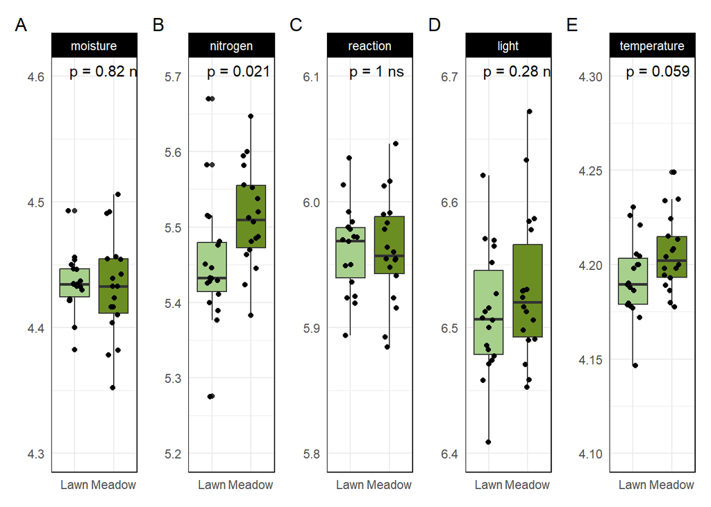

Figure 1: Boxplots showing differences in unweighted community means of ecological indicator values (EIVs) between meadows and lawns. A significant difference was observed for nitrogen values (B), with higher values in meadows. Temperature values tended to be higher in meadows but were not significantly different

```r
plot_eiv_unweighted
```

```r
ggsave(
  "plot_eiv_unweighted.jpg",
  plot=plot_eiv_unweighted,
  width=24,
  height=10,
  units = "cm"
)
```

## 2 Community-weighted means of functional traits

We can use the same approach to calculate the Community-weighted means (CWM) for functional traits. Calculate the CWM of the functional traits plant height (“canopy height”), seed mass and SLA. The trait data can be downloaded from: https://www.uni-oldenburg.de/en/landeco/research/leda/ (Kleyer et al. 2008)

**Tip**

Tip: There is a separate file for each trait, combine them first.

**Tip**

Tip 2: Check if the data of the traits are skewed and use a log10 transformation if necessary.

```r
canopy_height <- read_delim("data/canopy_height.txt") |>
  filter(valid==1)
seed_mass <- read_delim("data/seed_mass.txt") |>
  filter(valid==1)
sla <- read_delim("data/SLA.txt") |>
  filter(valid==1)

canopy_height |> str()
```

```
spc_tbl_ [4,566 × 17] (S3: spec_tbl_df/tbl_df/tbl/data.frame)
 $ SBS name                  : chr [1:4566] "Marsilea quadrifolia" "Pilularia globulifera" "Salvinia natans" "Azolla filiculoides" ...
 $ SBS number                : num [1:4566] 5 12 17 22 35 37 43 47 48 57 ...
 $ general method            : chr [1:4566] "derivation from photos or drawings" "derivation from photos or drawings" "derivation from photos or drawings" "derivation from photos or drawings" ...
 $ single value [m]          : num [1:4566] 0.1 0.075 0.02 0.02 1 0.65 0.3 0.3 0.3 0.9 ...
 $ sample size               : num [1:4566] NA NA NA NA NA NA NA NA NA NA ...
 $ valid                     : num [1:4566] 1 1 1 1 1 1 1 1 1 1 ...
 $ reference                 : chr [1:4566] "BIOPOP April 2005" "BIOPOP April 2005" "BIOPOP April 2005" "BIOPOP April 2005" ...
 $ mean CH [m]               : num [1:4566] NA NA NA NA NA NA NA NA NA NA ...
 $ maximum CH [m]            : num [1:4566] 0.15 0.1 0.03 0.03 1.5 1 0.5 0.45 0.4 1.5 ...
 $ minimum CH [m]            : num [1:4566] 0.05 0.05 0.01 0.01 0.5 0.3 0.1 0.15 0.2 0.3 ...
 $ number of replicates      : num [1:4566] NA NA NA NA NA NA NA NA NA NA ...
 $ standard deviation        : logi [1:4566] NA NA NA NA NA NA ...
 $ standard error            : logi [1:4566] NA NA NA NA NA NA ...
 $ collection date           : POSIXct[1:4566], format: NA NA ...
 $ original reference        : chr [1:4566] "J?ger, E.J. (2000): Rothmaler Exkursionsflora von Deutschland. Gef??pflanzen: Atlasband" "J?ger, E.J. (2000): Rothmaler Exkursionsflora von Deutschland. Gef??pflanzen: Atlasband" "J?ger, E.J. (2000): Rothmaler Exkursionsflora von Deutschland. Gef??pflanze…
 $ country                   : chr [1:4566] "GERMANY" "GERMANY" "GERMANY" "GERMANY" ...
 $ external support structure: chr [1:4566] "unknown" "unknown" "unknown" "unknown" ...
 - attr(*, "spec")=
  .. cols(
  ..   `SBS name` = col_character(),
  ..   `SBS number` = col_double(),
  ..   `general method` = col_character(),
  ..   `single value [m]` = col_double(),
  ..   `sample size` = col_double(),
  ..   valid = col_double(),
  ..   reference = col_character(),
  ..   `mean CH [m]` = col_double(),
  ..   `maximum CH [m]` = col_double(),
  ..   `minimum CH [m]` = col_double(),
  ..   `number of replicates` = col_double(),
  ..   `standard deviation` = col_logical(),
  ..   `standard error` = col_logical(),
  ..   `collection date` = col_datetime(format = ""),
  ..   `original reference` = col_character(),
  ..   country = col_character(),
  ..   `external support structure` = col_character()
  .. )
 - attr(*, "problems")=<externalptr>
```

```r
seed_mass |> str()
```

```
spc_tbl_ [6,285 × 17] (S3: spec_tbl_df/tbl_df/tbl/data.frame)
 $ SBS name            : chr [1:6285] "Acer campestre" "Acer campestre" "Acer campestre" "Acer campestre" ...
 $ SBS number          : num [1:6285] 811 811 811 811 811 811 811 811 811 811 ...
 $ general method      : chr [1:6285] "actual measurement" "actual measurement" "actual measurement" "actual measurement" ...
 $ diaspore type       : chr [1:6285] "one-seeded generative dispersule" "one-seeded generative dispersule" "generative dispersule" "germinule" ...
 $ single value [mg]   : num [1:6285] 14.4 18.2 68.9 18.2 14.4 ...
 $ sample size         : num [1:6285] 1 1 5 1 1 1 1 1 1 1 ...
 $ valid               : num [1:6285] 1 1 1 1 1 1 1 1 1 1 ...
 $ median              : num [1:6285] NA NA NA NA NA NA NA NA NA NA ...
 $ reference           : chr [1:6285] "Source data from University of Sheffield, Dept. of Animal and Plant Sciences, UK (Thompson), E-Mail: ken.thomps"| __truncated__ "Source data from University of Sheffield, Dept. of Animal and Plant Sciences, UK (Thompson), E-Mail: ken.thomps"| __truncated__ "Sou…
 $ mean SM [mg]        : num [1:6285] 14.4 18.2 68.9 18.2 14.4 ...
 $ maximum SM [mg]     : num [1:6285] NA NA 71.8 NA NA ...
 $ minimum SM [mg]     : num [1:6285] NA NA 66.4 NA NA ...
 $ number of replicates: num [1:6285] 10 25 50 25 10 1000 1000 1000 1000 1000 ...
 $ general comment     : chr [1:6285] NA NA NA NA ...
 $ Drying method       : chr [1:6285] "Air dried weight" "Air dried weight" "Air dried weight" "Air dried weight" ...
 $ original reference  : chr [1:6285] NA NA NA NA ...
 $ diaspore type code  : chr [1:6285] "2a" "2a" "2" "3" ...
 - attr(*, "spec")=
  .. cols(
  ..   `SBS name` = col_character(),
  ..   `SBS number` = col_double(),
  ..   `general method` = col_character(),
  ..   `diaspore type` = col_character(),
  ..   `single value [mg]` = col_double(),
  ..   `sample size` = col_double(),
  ..   valid = col_double(),
  ..   median = col_double(),
  ..   reference = col_character(),
  ..   `mean SM [mg]` = col_double(),
  ..   `maximum SM [mg]` = col_double(),
  ..   `minimum SM [mg]` = col_double(),
  ..   `number of replicates` = col_double(),
  ..   `general comment` = col_character(),
  ..   `Drying method` = col_character(),
  ..   `original reference` = col_character(),
  ..   `diaspore type code` = col_character()
  .. )
 - attr(*, "problems")=<externalptr>
```

```r
sla |> str()
```

```
spc_tbl_ [3,755 × 24] (S3: spec_tbl_df/tbl_df/tbl/data.frame)
 $ SBS name              : chr [1:3755] "Dactylis glomerata" "Festuca pratensis" "Lolium perenne" "Festuca ovina" ...
 $ general method        : chr [1:3755] "laboratory/greenhouse/garden experiment" "laboratory/greenhouse/garden experiment" "laboratory/greenhouse/garden experiment" "laboratory/greenhouse/garden experiment" ...
 $ single value [mm^2/mg]: num [1:3755] 16.8 19.8 22.2 16.8 17.6 ...
 $ sample size           : num [1:3755] 8 8 8 8 8 8 8 15 15 15 ...
 $ valid                 : num [1:3755] 1 1 1 1 1 1 1 1 1 1 ...
 $ leaf specific method  : chr [1:3755] "no leaf rehydration" "no leaf rehydration" "no leaf rehydration" "no leaf rehydration" ...
 $ reference             : chr [1:3755] "Arrendondo, J. Tulio(2003): Components of leaf elongation rate and their relationship to specific leaf area in ..." "Arrendondo, J. Tulio(2003): Components of leaf elongation rate and their relationship to specific leaf area in ..." "Arrendondo, J. Tulio(2003…
 $ SBS number            : num [1:3755] 40290 41343 43540 40171 40358 ...
 $ original reference    : chr [1:3755] "Arrendondo, J. Tulio(2003): Components of leaf elongation rate and their relationship to specific leaf area in ..." "Arrendondo, J. Tulio(2003): Components of leaf elongation rate and their relationship to specific leaf area in ..." "Arrendondo, J. Tulio(2003…
 $ country               : chr [1:3755] "Europe" "Europe" "Europe" "Europe" ...
 $ UTM zone              : num [1:3755] NA NA NA NA NA NA NA 0 0 0 ...
 $ UTM easting           : num [1:3755] 0 0 0 0 0 0 0 0 0 3.42 ...
 $ UTM northing          : num [1:3755] 0 0 0 0 0 ...
 $ mean SLA [mm^2/mg]    : num [1:3755] 16.8 19.8 22.2 16.8 17.6 ...
 $ maximum SLA [mm^2/mg] : num [1:3755] NA NA NA NA NA NA NA NA NA NA ...
 $ minimum SLA [mm^2/mg] : num [1:3755] NA NA NA NA NA NA NA NA NA NA ...
 $ number of replicates  : num [1:3755] 1 1 1 1 1 1 1 1 1 1 ...
 $ standard deviation    : num [1:3755] NA NA NA NA NA NA NA NA NA NA ...
 $ standard error        : num [1:3755] NA NA NA NA NA NA NA NA NA NA ...
 $ balance error [mg]    : num [1:3755] NA NA NA NA NA NA NA NA NA NA ...
 $ collection date       : 'hms' num [1:3755] 00:00:00 00:00:00 00:00:00 00:00:00 ...
  ..- attr(*, "units")= chr "secs"
 $ general comment       : chr [1:3755] NA NA NA NA ...
 $ plant stage           : chr [1:3755] "adult" "adult" "adult" "adult" ...
 $ ...24                 : chr [1:3755] NA NA NA NA ...
 - attr(*, "spec")=
  .. cols(
  ..   `SBS name` = col_character(),
  ..   `general method` = col_character(),
  ..   `single value [mm^2/mg]` = col_double(),
  ..   `sample size` = col_double(),
  ..   valid = col_double(),
  ..   `leaf specific method` = col_character(),
  ..   reference = col_character(),
  ..   `SBS number` = col_double(),
  ..   `original reference` = col_character(),
  ..   country = col_character(),
  ..   `UTM zone` = col_double(),
  ..   `UTM easting` = col_double(),
  ..   `UTM northing` = col_double(),
  ..   `mean SLA [mm^2/mg]` = col_double(),
  ..   `maximum SLA [mm^2/mg]` = col_double(),
  ..   `minimum SLA [mm^2/mg]` = col_double(),
  ..   `number of replicates` = col_double(),
  ..   `standard deviation` = col_double(),
  ..   `standard error` = col_double(),
  ..   `balance error [mg]` = col_double(),
  ..   `collection date` = col_time(format = ""),
  ..   `general comment` = col_character(),
  ..   `plant stage` = col_character(),
  ..   ...24 = col_character()
  .. )
 - attr(*, "problems")=<externalptr>
```

```r
canopy_height <- canopy_height |>
    select(
      ID=`SBS name`,
      canopy_height=`single value [m]`
    ) |>
  group_by(ID) |>
  summarise(canopy_height=canopy_height |> mean())

seed_mass <- seed_mass |>
    select(
      ID=`SBS name`,
      seed_mass=`single value [mg]`
    ) |>
  group_by(ID) |>
  summarise(seed_mass=seed_mass |> mean())

sla <- sla |>
    select(
      ID=`SBS name`,
      specific_leaf_area=`single value [mm^2/mg]`
    ) |>
  group_by(ID) |>
  summarise(specific_leaf_area=specific_leaf_area |> mean())

functional_traits <- full_join(
    canopy_height,
    seed_mass,
    join_by(
      ID
    )
  ) |>
  full_join(
    sla,
    join_by(
      ID
    )
  )
```

```r
vegA_2019_traits <- vegA_2019_species |>
  left_join(
    functional_traits,
    join_by(ID)
  )

vegA_2019_traits |>
  filter(
    is.na(canopy_height) |
    is.na(seed_mass) |
    is.na(specific_leaf_area)
  ) |>
  select(ID,canopy_height,seed_mass,specific_leaf_area) |>
  kable()
```

| ID | canopy_height | seed_mass | specific_leaf_area |
| --- | --- | --- | --- |
| Acer sp. | NA | NA | NA |
| Achillea millefolium aggr. | NA | NA | NA |
| Alchemilla sp. | NA | NA | NA |
| Bromus hordeaceus | NA | 2.2515142 | 24.88000 |
| c.f. Brassica sp. | NA | NA | NA |
| c.f. Cerastium sp. | NA | NA | NA |
| Carex sp. | NA | NA | NA |
| Cerastium fontanum subsp. vulgare | NA | NA | NA |
| Epilobium sp. | NA | NA | NA |
| Equisetum arvense | 0.325 | NA | 9.90099 |
| Erigeron annuus | 0.675 | NA | 34.20000 |
| Galium mollugo aggr. | NA | NA | NA |
| Hypochaeris radicata | NA | NA | NA |
| Lysimachia nummularia | 0.450 | NA | 27.17266 |
| Poa trivialis | NA | 0.1649333 | 31.13998 |
| Rhinanthus alectorolophus | 0.450 | 3.6000000 | NA |
| Salix sp. | NA | NA | NA |
| Taraxacum officinale aggr. | NA | NA | NA |
| Trifolium sp. | NA | NA | NA |
| Veronica cf. chamaedrys | NA | NA | NA |
| Veronica filiformis | 0.175 | NA | 35.92500 |
| Veronica sp. | NA | NA | NA |

```r
name_traits_map <- c(
  "Achillea millefolium aggr." = "Achillea millefolium",
  "Cerastium fontanum subsp. vulgare" = "Cerastium fontanum",
  "Galium mollugo aggr." = "Galium mollugo",
  "Taraxacum officinale aggr." = "Taraxacum officinale"
)

vegA_2019_traits_corrected <- vegA_2019_species |>
  mutate(
    ID_orig = ID,
    ID = recode(as.character(ID), !!!name_traits_map),
    ID = factor(ID)
  ) |>
  left_join(
    functional_traits,
    join_by(
      ID
    )
  )
```

```r
plot_traits_hist <-  vegA_2019_traits_corrected |>
  select(canopy_height,seed_mass,specific_leaf_area) |>
  pivot_longer(cols=canopy_height:specific_leaf_area) |>
  ggplot(aes(value))+
  geom_histogram()+
  facet_wrap(.~name, scale="free")

plot_traits_hist_log <- vegA_2019_traits_corrected |>
  select(canopy_height,seed_mass,specific_leaf_area) |>
  pivot_longer(cols=canopy_height:specific_leaf_area) |>
  ggplot(aes(value))+
  scale_x_log10()+
  geom_histogram()+
  facet_wrap(.~name, scale="free")

plot_traits <- plot_traits_hist +
  plot_traits_hist_log +
  plot_annotation(tag_levels = "A") +
  plot_layout(ncol = 1)
```

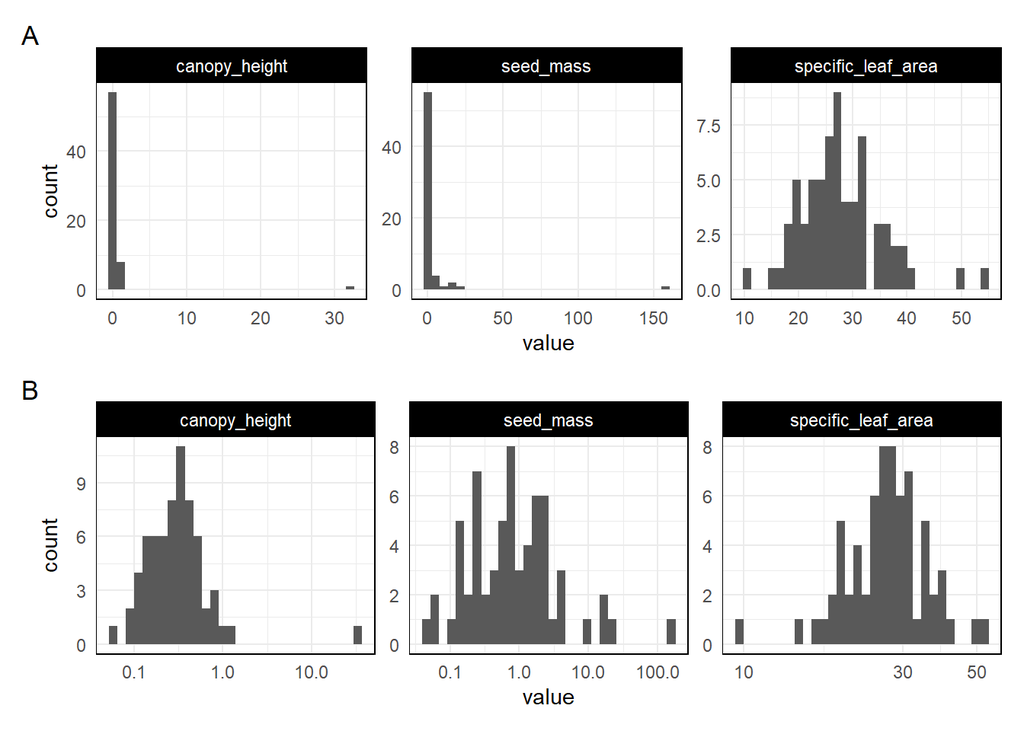

Figure 2: Historgram of the traits data (A) without and (B) with log10 transformation

```r
plot_traits
```

```r
traits <- vegA_2019_traits_corrected |>
  select(ID, canopy_height, seed_mass, specific_leaf_area) |>
  mutate(
    canopy_height=canopy_height |> log10(),
    seed_mass=seed_mass |> log10()
  ) |>
  column_to_rownames("ID")

abundances <- vegA_2019_traits_corrected |>
  select(ID, starts_with("CH")) |>
  column_to_rownames("ID") |>
  as.matrix() |>
  t()

vegA_2019_traits_cwm <- functcomp(traits, abundances) |>
  mutate(
    Plot = rownames(abundances)
  )
```

```r
vegA_2019_traits_cwm_plotdata <- vegA_2019_traits_cwm |>
  left_join(
    vegA_2019_header |>
      select(Plot_2...1, Landuse),
    join_by(Plot==Plot_2...1)
  )
```

```r
aov(canopy_height ~ Landuse, data=vegA_2019_traits_cwm_plotdata) |> summary()
```

```
            Df Sum Sq Mean Sq F value Pr(>F)
Landuse      1 0.0206 0.02060   1.245  0.272
Residuals   34 0.5627 0.01655
```

```r
aov(seed_mass ~ Landuse, data=vegA_2019_traits_cwm_plotdata) |> summary()
```

```
            Df Sum Sq Mean Sq F value Pr(>F)
Landuse      1 0.0550 0.05501   1.875   0.18
Residuals   34 0.9973 0.02933
```

```r
aov(specific_leaf_area~Landuse, data=vegA_2019_traits_cwm_plotdata) |> summary()
```

```
            Df Sum Sq Mean Sq F value  Pr(>F)
Landuse      1  46.12   46.12   12.93 0.00101 **
Residuals   34 121.26    3.57
---
Signif. codes:  0 '***' 0.001 '**' 0.01 '*' 0.05 '.' 0.1 ' ' 1
```

```r
vegA_2019_traits_cwm_plotdata |>
  select(Plot,canopy_height,seed_mass,specific_leaf_area, Landuse) |>
  summary()
```

```
     Plot           canopy_height       seed_mass        specific_leaf_area
 Length:36          Min.   :-0.9158   Min.   :-0.44823   Min.   :22.67
 Class :character   1st Qu.:-0.6958   1st Qu.:-0.18160   1st Qu.:25.80
 Mode  :character   Median :-0.6154   Median :-0.09717   Median :27.69
                    Mean   :-0.6193   Mean   :-0.08798   Mean   :27.37
                    3rd Qu.:-0.5534   3rd Qu.:-0.01635   3rd Qu.:28.92
                    Max.   :-0.2949   Max.   : 0.39587   Max.   :32.77
   Landuse
 Length:36
 Class :character
 Mode  :character
```

```r
plot_canopy_height <- vegA_2019_traits_cwm_plotdata |>
  ggplot(aes(Landuse, canopy_height, fill=Landuse)) +
  geom_boxplot()+
  geom_jitter(width=0.2)+
  stat_compare_means(
    method = "anova",
    aes(label = paste0("p = ", ..p.format.., " ", ..p.signif..)),
    label.x = 1.25
  )+
  scale_fill_manual(
    values=landuse_colormap
  )+
  labs(x = NULL, y = "log10(m)")+
  facet_wrap(.~"canopy height")+
  theme(legend.position = "none")

plot_seed_mass <- vegA_2019_traits_cwm_plotdata |>
  ggplot(aes(Landuse, seed_mass, fill=Landuse)) +
  geom_boxplot()+
  geom_jitter(width=0.2)+
  stat_compare_means(
    method = "anova",
    aes(label = paste0("p = ", ..p.format.., " ", ..p.signif..)),
    label.x = 1.25
  )+
  scale_fill_manual(
    values=landuse_colormap
  )+
  labs(x = NULL, y = "log10(mg)")+
  facet_wrap(.~"seed mass")+
  theme(legend.position = "none")

plot_specifig_leaf_area <- vegA_2019_traits_cwm_plotdata |>
  ggplot(aes(Landuse, specific_leaf_area, fill=Landuse)) +
  geom_boxplot()+
  geom_jitter(width=0.2)+
  stat_compare_means(
    method = "anova",
    aes(label = paste0("p = ", ..p.format.., " ", ..p.signif..)),
    label.x = 1.25
  )+
  scale_fill_manual(
    values=landuse_colormap
  )+
  labs(x = NULL, y = "mm^2/mg")+
  facet_wrap(.~"SLA")+
  theme(legend.position = "none")

plot_traits_cwm <- plot_canopy_height +
  plot_seed_mass +
  plot_specifig_leaf_area +
  plot_annotation(tag_levels = "A")
```

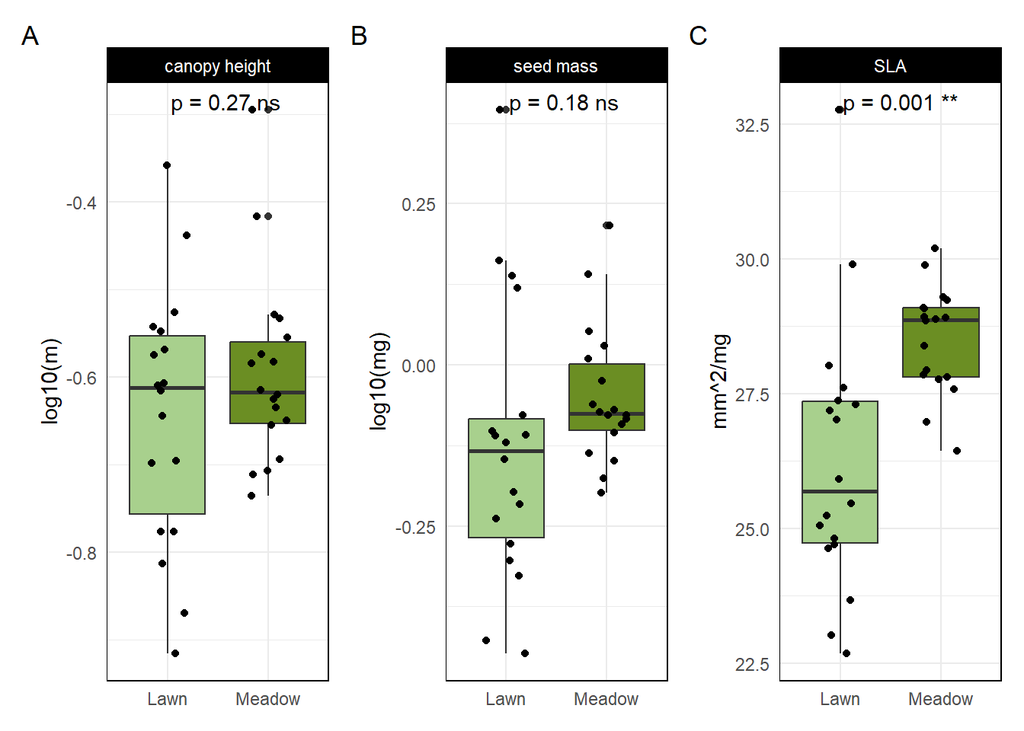

Figure 3: Boxplots illustrating differences in community-weighted means of functional traits ((A) canopy height, (B) seed mass, and (C) specific leaf area) between meadows and lawns. A significant difference was observed for SLA, with higher values in meadows. No significant differences were found for canopy height and seed mass.

```r
plot_traits_cwm
```

```r
ggsave(
  "plot_traits_cwm.jpg",
  plot=plot_traits_cwm,
  width=24,
  height=10,
  units = "cm"
)
```

## References

Dengler, Jürgen, Florian Jansen, Olha Chusova, Elisabeth Hüllbusch, Michael P. Nobis, Koenraad Van Meerbeek, Irena Axmanová, et al. 2023. “Ecological Indicator Values for Europe (EIVE) 1.0.” *Vegetation Classification and Survey* 4: 7–29. https://doi.org/10.3897/VCS.98324.

Kleyer, M., R. M. Bekker, I. C. Knevel, J. P. Bakker, K. Thompson, M. Sonnenschein, P. Poschlod, et al. 2008. “The LEDA Traitbase: A Database of Life-History Traits of the Northwest European Flora.” *Journal of Ecology* 96: 1266–74. https://doi.org/10.1111/j.1365-2745.2008.01430.x.

R Core Team. 2025. *R: A Language and Environment for Statistical Computing*. Vienna, Austria: R Foundation for Statistical Computing. https://www.R-project.org/.